# Working with R

Ben Whalley, Paul Sharpe, Sonja Heintz

# Overview

**Make sure you are confident with all the material in the previous ‘getting started’ session before continuing.**

Here we introduce extra tricks for working with RStudio that are important to build confidence and make you productive.

At the end of the session, you will have used variables to store the result of your calculations, loaded data into R from a file, and used commands to select and summarise subsets of the data. These are important building blocks for later sessions.

# Techniques covered

- Storing data in variables
- Passing data with pipes `%>%`
- Loading data from elsewhere
- Selecting rows with `filter()`
- Summarising data using `summarise()`
- Learning how to fix broken code

# Storing data in variables

[video not shown]

**Video summary**

- In R, a **variable** is the name for a *container*
- Variables can contain anything — not just data
- *Columns* in a dataset sometimes get called variables too (sorry)
- Create variables with **`<-`** (called the *assignment operator*)
- The order is: `name_of_variable <- stuff_being_stored`
- Use short, descriptive names. Don’t use spaces or capitals

**Code examples**

```r
# assign the current year to a variable
current_year <- 2021

# print the variable we created
# (it should display below the chunk, or in the console pane)
current_year

# do a calculation to create a new variable from an existing one
next_year <- current_year + 1
```

**Video Transcript**

Each instruction we give R produces a result.

By default, these results are shown below the code chunk.

Sometimes, though, we’d like to save the results. Perhaps we want to use them in another calculation later?

To do this we can create a **variable**.

A variable is just a *container*. We can store things in it: the results of simple calculations, datasets, tables, plots, or even statistical models.

To make variables we use the assignment operator, which looks like this `<-`.

It looks like an arrow that points to the left, but it’s made up of an angle bracket and a hyphen, placed next to each other.

The arrow is a reminder that the value on the right hand side will be assigned (stored) in the variable named on the left hand side.

For example, we can write this:

```r
# assign the current year to a variable
current_year <- 2021
```

And we now have a variable called `current_year` which contains the number `2021`.

The simplest way to check what a variable contains is to write it’s name, and then run that line of code:

```r
# print the variable we created to the console window
current_year
[1] 2021
```

You might wonder *where* these variables get saved. In most cases, variables you create are stored in what’s called the `Global Environment`. You can see them in the **Environment** pane in RStudio.

[HIGHLIGHT NAME AND VALUE OF A VARIABLE IN THE ENVIRONMENT.]

Once stored, we can use variables as the *input* to new calculations.

For example, in this example we are adding 1 to the current year and storing the result in another variable called `next_year`:

```r
# do a calculation to create a new variable from an existing one
next_year <- current_year + 1
```

Naming variables sensibly is more important than you might realise.

You will save yourself a lot of trouble if you give your variables short names which describe the data they contain. Use the underscore `_` if you need to use more than one word e.g. `current_year`.

Variable names can’t contain spaces, and it’s best to avoid special characters or capital letters.

**Exercise 1**

1. Open `session-2.rmd` using the **Files** pane. This is the workbook you will be using in this session.
2. Run the first chunk in the workbook.

The output should look like this:

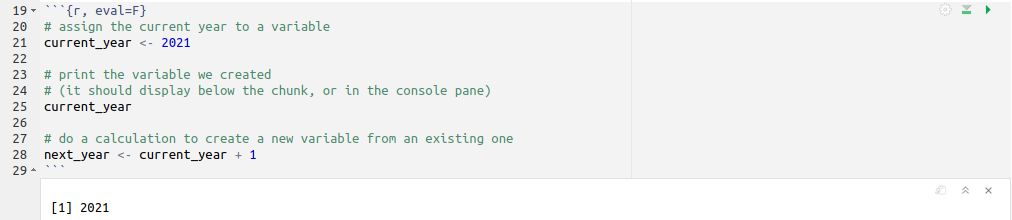

Chunk which creates variables and prints a variable’s value

Your **Environment** pane should look like this:

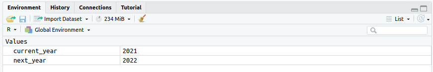

Environment pane after creating variables

**Exercise 2**

1. Create a new chunk below the `Exercise 2` heading in your workbook (`session-2.rmd`).
2. Assign the results of the calculation `2 * 35` to the variable `seventy`
3. Run the chunk

Your **Environment** should now look like this:

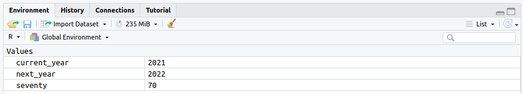

Environment pane after creating new variable

**Exercise 3**

1. Create a new chunk below the `Exercise 3` heading in your workbook.
2. Use R to calculate your age in the year 2051.
3. Save the result in a variable *with a descriptive name*.

# Passing data with pipes `%>%`

[video not shown]

**Video summary**

- The **pipe** passes data from one piece of code to another
- The pipe looks like this: `%>%`
- Type `Ctrl + Shift + M` to add a pipe (use `⌘` on Macs)
- A **pipeline** is a list of operations, joined by pipes
- Store the pipe output in a variable (using `<-`)

**Code examples**

```r
# pipe mtcars into head()
mtcars %>% head()

# store first few rows of mtcars
mtcars_head <- mtcars %>%
  head()
```

**Video Transcript**

We often need to link a few commands together which modify data before analysing it.

For example, if we’re working with a big dataset we might only want analyse part of the data. We could do this in stages by selecting only the columns we want to analyse, filtering out any rows we don’t want to analyse, and then calculating some descriptive statistics for the data that’s left.

One way to do this would be to use variables to save the results of each stage, but this would produce lots of variables which can get confusing.

A different approach is to use what’s known as a ‘pipe’ — it’s another way to link together multiple instructions.

The pipe sends data from one piece of code to another.

It looks like this `%>%`.

Press `Ctrl + Shift + M` (Windows/Linux) or `⌘ + Shift + M` (Mac) to add a pipe.

In session 1, you used the following code to “pipe” the `mtcars` dataset into `head()`, which shows just the first few rows:

```r
mtcars %>% head()
                   mpg cyl disp  hp drat    wt  qsec vs am gear carb
Mazda RX4         21.0   6  160 110 3.90 2.620 16.46  0  1    4    4
Mazda RX4 Wag     21.0   6  160 110 3.90 2.875 17.02  0  1    4    4
Datsun 710        22.8   4  108  93 3.85 2.320 18.61  1  1    4    1
Hornet 4 Drive    21.4   6  258 110 3.08 3.215 19.44  1  0    3    1
Hornet Sportabout 18.7   8  360 175 3.15 3.440 17.02  0  0    3    2
Valiant           18.1   6  225 105 2.76 3.460 20.22  1  0    3    1
```

You can think of your data as flowing along lengths of pipe, joined by functions which do things to the data, step by step, until the result you want plops out at the end.

Each `%>%` should be read as the word “then”, e.g. “pipe the `mtcars` dataset, *then* `head()` it”.

The `>` in the pipe function reminds you of the direction in which your data is flowing (it only works left to right).

It’s important to know that the pipe *doesn’t store the results* of these steps.

Sometimes that’s OK. In our first example we just wanted to look at the first few rows of the `mtcars` data.

But, you will usually want to save the result of a pipeline in a new variable.  
For example, if we wanted to save the first few rows of the `mtcars` data to a *new* variable we would write:

```r
mtcars_head <- mtcars %>% head()
```

Here we combine *assignment* with a *pipeline*.

Remember that it is the final result of the commands on the right hand side of the `<-` that are assigned to the variable.

The result of the pipeline (a `data.frame` containing the first few rows of `mtcars`) is saved to a new variable called `mtcars_head`.

You can explore your variables using the **Environment** pane. A `data.frame` will have an icon that looks like a spreadsheet. If you click on the icon, the `data.frame` is displayed in a new tab in the **Source** pane.

- click on the `mtcars_head` icon

This tab shows you the same information as printing the `data.frame`, such as the number of rows and columns, but it also provides tools for exploring the data interactively.

- The arrows next to the column names allow you to arrange the rows in ascending or descending order based on the column values.
- The `Filter` button allows you to specify a value for one or more columns to filter out non-matching rows. For example, we could display just cars with 4 gears. Click the button again to turn off the filter.

**Exercise 4**

1. Create a new chunk below the `Exercise 4` heading in your workbook.
2. Load the `tidyverse` library.
3. Pipe the `fuel` dataset into `head()` and assign the results to a variable called `fuel_head`.
4. Use the **Environment** pane to open `fuel_head`.

# Loading data from elsewhere

[video not shown]

**Video summary**

File formats:

- R can load almost any data format
- We recommend comma-separated value (CSV) files
- CSV filenames always end in `.csv`
- You can also open CSV files in Excel

Loading data:

- Always use `read_csv()` (NOT `read.csv()`)
- Upload your file to the RStudio server first (use the **Files** pane)
- Save/upload data to the **same folder as your `.rmd` file**

Remember to:

- Assign (`<-`) the result of `read_csv()` to a variable
- Give the variable a descriptive name
- Use `glimpse` or the **Environment** pane to check imported data

**Code examples**

*Remember*: This code relies on you first uploading your CSV data to the correct folder on the RStudio server. if you have problems see below or re-watch the video.

### Preparation

Before you run the code below, we asked you to:

1. Download the CSV file from here: https://benwhalley.github.io/lifesavR/data/shootings.csv and save it to you *Desktop Folder*. Then,
2. Upload it to the RStudio Server, in the same place as your Rmd worksheets
3. Step is to use the code BELOW

```r
#read the CSV and assign it to a new variable, called `shootings`
shootings <- read_csv('shootings.csv')


# now we can inspect this dataset like any other:
shootings %>% glimpse
```

### Troubleshooting

If you see the error below it means you have not uploaded the data file (`.csv`) to the same place as your `.Rmd` worksheet, so check that first, and try uploading it again:

```
Error: 'shootings.csv' does not exist in current working directory ('/home/username').
```

If you get this error or similar, it means you haven’t loaded `tidyverse` yet:

```
Error in read_csv("shootings.csv") : could not find function "read_csv"
```

**Video Transcript**

In a lot of these workshops we use datasets that are built-in to R, or are part of the `psydata` package. This is a convenient way to illustrate the points we make.

- open and use `glance` on some built in data like iris, mtcars etc, or `development`, `happy`, from `psydata`

Later, though, you will need to load your own data.

R can read many different file formats, including Excel files (`.xlsx` or `.xls`), and files generated by other packages like SPSS.

To keep things simple, reproducible and future proof we recommend *comma separated values* (CSV) files, which have the file extension `.csv`. (The final 3 or 4 letters of a filename, after the full stop, is called the file extension).

### Loading CSV data

There are 3 steps you must follow:

1. Collect or otherwise get hold of the CSV file you want to load
2. Upload it to the RStudio server, in the same place as your R code (`.rmd` file)
3. Use `read_csv()`, and assign the result to a variable with a descriptive name

### Step 1. Collect or get the data

If you are using your own data then you will have collected it using experimental software like OpenSesame, an online survey tool like SurveyMonkey, or recorded it yourself in a spreadsheet. In any of these cases, you will need to export the data to a `.csv` file.

You may also be sent CSV data by email, or download it from the web. That’s what we’ll practice now.

The following URL is for a file called `shootings.csv`.

- https://benwhalley.github.io/lifesavR/data/shootings.csv

To save a copy to the computer you are working at, right-click on the link and choose:

- “Save link as…” (Chrome/Firefox/Edge)
- “Download linked file as” (Safari)

Your computer will ask you where you want to save it. For now, you should choose your `Desktop` folder.

- demonstrate saving the file at this URL to the user’s `Desktop Folder`

### Step 2. Upload data to the RStudio server

In these workshops we are using the RStudio server.

This means R is running on a different computer to the one you are working on, and can’t access the files on your `Desktop`.

We need to upload the `.csv` file to the server before we can load them.

- Go to the **Files** pane in the RStudio interface
- Make sure you can see the `.rmd` workbook files in the **Files** pane. This means you are “in” the same folder as the `.rmd` files (R calls this your *working directory*)
- Press the ‘Upload’ button
- Click `Choose file` and choose the `.csv` you want to upload from your LOCAL computer. In this example it will be the file `shootings.csv` that you saved to your Desktop folder in Step 1.
- Click **`OK`**
- demonstrate all of these steps

Finally, use the **Files** pane to check that `shootings.csv` is in the same directory as `session-2.rmd`.

If you can see both files you are ready to carry on.

### Step 3. Use `read_csv()` and assign the result to a variable

In your workbook file (`session-2.rmd`) create a new code chunk (the keyboard shortcut is `Ctrl (or ⌘) + Alt + I`) below the heading `Loading data from elsewhere`.

Use `read_csv()` to load the file, like this:

```r
read_csv('shootings.csv')
```

If you run this line of code you will see the imported data appear below the code chunk.

HOWEVER, you’re not quite finished.

R *has* imported the data, and shown it on screen, but it hasn’t — yet — stored it anywhere.

To do that we need to assign the result of `read_csv()` to a variable:

```r
shootings <- read_csv('shootings.csv')
```

### Checking it worked

Now we have assigned the result of `read_csv()` to a variable, we can use this dataset like any other (including the built-in ones):

```r
shootings %>% glimpse()
Rows: 4,895
Columns: 15
$ id                      <dbl> 3, 4, 5, 8, 9, 11, 13, 15, 16, 17, 19, 21, 22, 25, 27, 29, 32, 36, 37, 38, 325, 42, 43, 45, 46…
$ name                    <chr> "Tim Elliot", "Lewis Lee Lembke", "John Paul Quintero", "Matthew Hoffman", "Michael Rodriguez"…
$ date                    <date> 2015-01-02, 2015-01-02, 2015-01-03, 2015-01-04, 2015-01-04, 2015-01-04, 2015-01-05, 2015-01-0…
$ manner_of_death         <chr> "shot", "shot", "shot and Tasered", "shot", "shot", "shot", "shot", "shot", "shot", "shot", "s…
$ armed                   <chr> "gun", "gun", "unarmed", "toy weapon", "nail gun", "gun", "gun", "gun", "unarmed", "toy weapon…
$ age                     <dbl> 53, 47, 23, 32, 39, 18, 22, 35, 34, 47, 25, 31, 41, 30, 37, 28, 42, 36, 49, 71, 33, 39, 23, 29…
$ gender                  <chr> "M", "M", "M", "M", "M", "M", "M", "M", "F", "M", "M", "M", "M", "M", "M", "M", "M", "M", "M",…
$ race                    <chr> "Asian", "White", "Hispanic", "White", "Hispanic", "White", "Hispanic", "White", "White", "Bla…
$ city                    <chr> "Shelton", "Aloha", "Wichita", "San Francisco", "Evans", "Guthrie", "Chandler", "Assaria", "Bu…
$ state                   <chr> "WA", "OR", "KS", "CA", "CO", "OK", "AZ", "KS", "IA", "PA", "CA", "TX", "OH", "IA", "LA", "MT"…
$ signs_of_mental_illness <lgl> TRUE, FALSE, FALSE, TRUE, FALSE, FALSE, FALSE, FALSE, FALSE, FALSE, FALSE, FALSE, TRUE, FALSE,…
$ threat_level            <chr> "attack", "attack", "other", "attack", "attack", "attack", "attack", "attack", "other", "attac…
$ flee                    <chr> "Not fleeing", "Not fleeing", "Not fleeing", "Not fleeing", "Not fleeing", "Not fleeing", "Car…
$ body_camera             <lgl> FALSE, FALSE, FALSE, FALSE, FALSE, FALSE, FALSE, FALSE, TRUE, FALSE, FALSE, FALSE, FALSE, FALS…
$ arms_category           <chr> "Guns", "Guns", "Unarmed", "Other unusual objects", "Piercing objects", "Guns", "Guns", "Guns"…
```

You could also use the **Environment** pane to examine the `shootings` variable if you prefer.

- Remind how to use Environment pane

**Exercise 5**

1. Use your web browser to download https://benwhalley.github.io/lifesavR/data/world-happiness-report-2021.csv to your computer.
2. Upload `world-happiness-report-2021.csv` to the server.
3. Create a new chunk below the `Exercise 5` heading in your workbook.
4. Read `world-happiness-report-2021.csv` into a variable with a descriptive name.

Which country had the highest **Healthy life expectancy**?

# Selecting rows with `filter()`

[video not shown]

**Video summary**

- `filter()` selects *rows* from a dataset
- We define criteria to match rows we want
- To match exactly, we use `==` (two equals symbols)
- Other filters like `<` (less than) or `>` (greater than) are also useful
- Combine multiple filters to be more specific
- Upper/lower case, spaces, and punctuation all matter (watch out!)

**Code examples**

```r
# load example data
library(psydata)

# filter on a categorical variable
# == means 'match exactly'
development %>%
  filter(country == "Kenya")

# this doesn't match any rows because the data spells Kenya with a capital 'K'
development %>%
  filter(country == "kenya")

# filtering on a numeric variable
development %>% filter(year > 2000)


# combining multiple filters makes things more specific
development %>%
  filter(country == "Kenya") %>%
  filter(year > 2000)

# assign filtered data to a new variable for re-use later on
# if you don't store the data, it is displayed but then lost
development.europe <- development %>%
  filter(continent == "Europe") %>%
  filter(year > 1980)

# show the stored subset
development.europe

# make a plot with the subset
development.europe %>%
    ggplot(aes(gdp_per_capita, life_expectancy)) +
  geom_point()
```

**Video Transcript**

Some datasets are very large. We often want to work with a subset of the data, and `filter` makes this possible.

### Categorical and text filters

The following chunk filters the `development` dataset (from `psydata`) to include only rows where the `country` column equals “Kenya”.

```r
library(psydata)

development %>%
  filter(country == "Kenya")
# A tibble: 12 x 6
   country continent  year life_expectancy population gdp_per_capita
   <fct>   <fct>     <int>           <dbl>      <int>          <dbl>
 1 Kenya   Africa     1952            42.3    6464046           854.
 2 Kenya   Africa     1957            44.7    7454779           944.
 3 Kenya   Africa     1962            47.9    8678557           897.
 4 Kenya   Africa     1967            50.7   10191512          1057.
 5 Kenya   Africa     1972            53.6   12044785          1222.
 6 Kenya   Africa     1977            56.2   14500404          1268.
 7 Kenya   Africa     1982            58.8   17661452          1348.
 8 Kenya   Africa     1987            59.3   21198082          1362.
 9 Kenya   Africa     1992            59.3   25020539          1342.
10 Kenya   Africa     1997            54.4   28263827          1360.
11 Kenya   Africa     2002            51.0   31386842          1288.
12 Kenya   Africa     2007            54.1   35610177          1463.
```

The `==` is called an “operator”. It compares values from the column on the left hand side with the value specified on the right hand side.

The value we are filtering for *must* match the column type.

The value `"Kenya"` was in quotes because the country column is a factor (not numeric), and we need to match the text of the name of the country.

It’s important to be accurate when matching text. Capitalisation, punctuation and spaces all matter, so you need to be precise. Copy and paste wherever you can. For example:

```r
development %>%
  filter(country=="kenya")
# A tibble: 0 x 6
# … with 6 variables: country <fct>, continent <fct>, year <int>, life_expectancy <dbl>, population <int>, gdp_per_capita <dbl>
```

This doesn’t match any rows because from R’s point of view `"kenya"` and `"Kenya"` are completely different!

### Numeric filters

The “greater than” operator `>` filters on numeric columns. For example, `year` is a column in the `development` dataset.

```r
development %>% filter(year > 2000)
# A tibble: 284 x 6
   country     continent  year life_expectancy population gdp_per_capita
   <fct>       <fct>     <int>           <dbl>      <int>          <dbl>
 1 Afghanistan Asia       2002            42.1   25268405           727.
 2 Afghanistan Asia       2007            43.8   31889923           975.
 3 Albania     Europe     2002            75.7    3508512          4604.
 4 Albania     Europe     2007            76.4    3600523          5937.
 5 Algeria     Africa     2002            71.0   31287142          5288.
 6 Algeria     Africa     2007            72.3   33333216          6223.
 7 Angola      Africa     2002            41.0   10866106          2773.
 8 Angola      Africa     2007            42.7   12420476          4797.
 9 Argentina   Americas   2002            74.3   38331121          8798.
10 Argentina   Americas   2007            75.3   40301927         12779.
# … with 274 more rows
```

The code above filters rows where `year` is greater than 2000, showing us the result.

The opposite of the `>` operator is the `<` operator. This filters numeric columns which are *less than* a value.

### Combined filters

You can combine filters in a pipeline to filter rows using multiple operators.

```r
development %>%
  filter(country == "Kenya") %>%
  filter(year > 2000)
# A tibble: 2 x 6
  country continent  year life_expectancy population gdp_per_capita
  <fct>   <fct>     <int>           <dbl>      <int>          <dbl>
1 Kenya   Africa     2002            51.0   31386842          1288.
2 Kenya   Africa     2007            54.1   35610177          1463.
```

This code filters rows leaving those where the country is `Kenya` and the year is greater than `2000`.

### Storing and re-using filtered data

When filtering, it’s common to want to save a subset of a dataset to use again.

For example, we might want to filter the data, make a table, and then also make a plot.

The key step is to *assign your filtered data to a new variable*.

For example:

```r
development.europe <- development %>%
  filter(continent == "Europe") %>%
  filter(year > 1980)
```

This code filters rows leaving us with data for European countries after 1980.

Importantly, it also stores this data in a *new variable*, called `development.europe`.

We can look at this new subset of the data by typing and running its name, or by looking in the **Envrionment** pane.

- Demonstrate evaluating data subset and exploring this using the environment pane.

Now that it is stored in a new variable, we can use these data in other code, for example to make a plot:

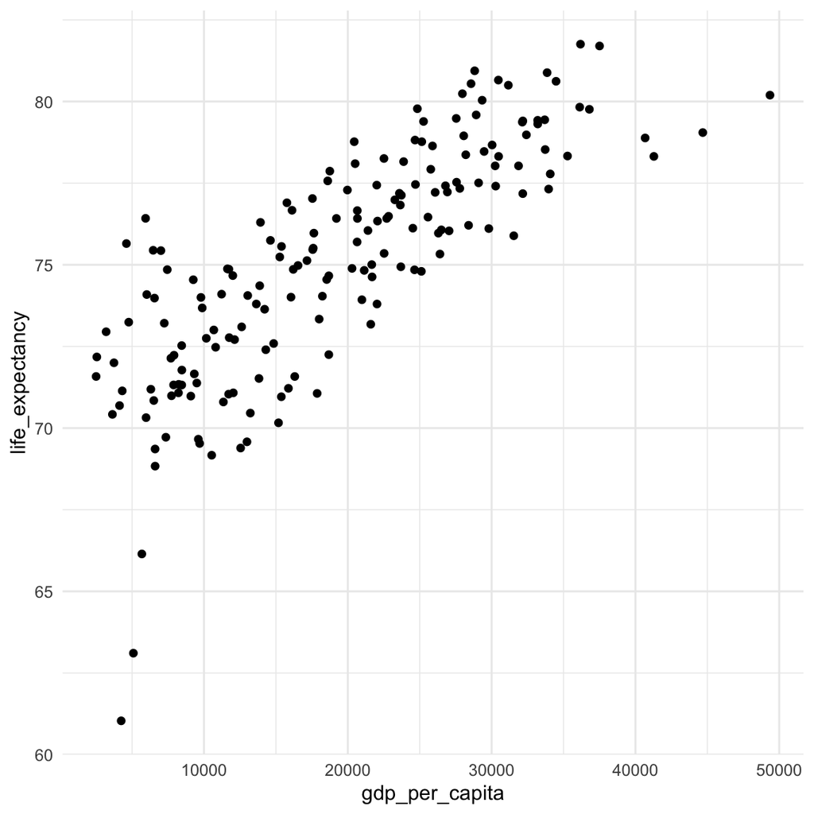

```r
development.europe %>%
    ggplot(aes(gdp_per_capita, life_expectancy)) +
  geom_point()
```

Or to calculate descriptive statistics for particular groups in the data (see the next section).

### Don’t forget to store filtered data

Beginners often forget to assign their filtered data to a new variable. Make sure you give your variables short but descriptive names so you know what they are.

**Exercise 6**

Filter the `development` dataset to show countries with a population greater than 100 million.

Your results should look like this:

```
# A tibble: 77 x 6
   country    continent  year life_expectancy population gdp_per_capita
   <fct>      <fct>     <int>           <dbl>      <int>          <dbl>
 1 Bangladesh Asia       1987            52.8  103764241           752.
 2 Bangladesh Asia       1992            56.0  113704579           838.
 3 Bangladesh Asia       1997            59.4  123315288           973.
 4 Bangladesh Asia       2002            62.0  135656790          1136.
 5 Bangladesh Asia       2007            64.1  150448339          1391.
 6 Brazil     Americas   1972            59.5  100840058          4986.
 7 Brazil     Americas   1977            61.5  114313951          6660.
 8 Brazil     Americas   1982            63.3  128962939          7031.
 9 Brazil     Americas   1987            65.2  142938076          7807.
10 Brazil     Americas   1992            67.1  155975974          6950.
# … with 67 more rows
```

**Exercise 7**

Show countries with a population greater than 100 million and life expectancy greater than 70.

The results should look like this:

```
# A tibble: 27 x 6
   country   continent  year life_expectancy population gdp_per_capita
   <fct>     <fct>     <int>           <dbl>      <int>          <dbl>
 1 Brazil    Americas   2002            71.0  179914212          8131.
 2 Brazil    Americas   2007            72.4  190010647          9066.
 3 China     Asia       1997            70.4 1230075000          2289.
 4 China     Asia       2002            72.0 1280400000          3119.
 5 China     Asia       2007            73.0 1318683096          4959.
 6 Indonesia Asia       2007            70.6  223547000          3541.
 7 Japan     Asia       1967            71.4  100825279          9848.
 8 Japan     Asia       1972            73.4  107188273         14779.
 9 Japan     Asia       1977            75.4  113872473         16610.
10 Japan     Asia       1982            77.1  118454974         19384.
# … with 17 more rows
```

# Summarising data using `summarise()`

[video not shown]

**Video summary**

- Summarising data means reducing lots of numbers to a smaller number
- For example, the mean is a summary which tells us about the central tendency
- `summarise()` allows us to use different *summary functions* like `mean()`, `median()` or `sd()` (standard deviation)
- It reduces many rows into a smaller number (sometimes a single number)
- `summarise()` returns a new dataset
- You can store the result in a variable, or use it in later code
- You can use `filter()` and `summarise()` together

**Code examples**

```r
# use function mean() to summarise mpg column
# the result is a data.frame with a single column named 'mean_mpg'
fuel %>%
  summarise(mean_mpg = mean(mpg))

# if you omit the column name, the summarised column is named after the summary function
# this produces column names which can be awkward to process later in a pipeline
# for example:
fuel %>%
  summarise(mean(mpg))

# median mpg (rather than mean)
fuel %>%
  summarise(median_mpg = median(mpg))

# standard deviation
fuel %>%
  summarise(sd_mpg = sd(mpg))

# summarise two columns at once
# the mean and sd functions are separated with a comma
# the resulting data frame is stored in a variable called fuel_summary
fuel_summary <- fuel %>%
  summarise(m = mean(mpg), sd = sd(mpg))

# see the stored summary
fuel_summary

# remember, this summary is still a new dataset; you could do more processing on it in extra steps if needed

# combining filter() and summarise()
development %>%
  filter(continent=="Asia") %>%
  summarise(Average_life_expectancy = mean(life_expectancy))
```

**Video Transcript**

Patterns within a dataset are often easier to see after the data is summarised.

Summarising data means reducing lots of numbers to a smaller number.

For example, the mean is a summary which tells us about the central tendency.

To summarise data in R, we use `summarise()`, with a “summary function” which reduces some data values.

For example, the `mean()` summary function calculates the mean of some data values, in this case the `mpg` column:

```r
fuel %>%
  summarise(mean_mpg = mean(mpg))
  mean_mpg
1 20.09062
```

The result is a `data.frame` with a single column named `mean_mpg` (`mean_mpg =` defined the column name).

If you don’t assign the result of the summary function to a column name, it is named after the summary function:

```r
fuel %>%
  summarise(mean(mpg))
  mean(mpg)
1  20.09062
```

You should normally specify a column name, because columns named after summary functions are awkward to process later in a pipeline.

The mean is just one of many summary functions.

We could also summarise `mpg` using a different measure of central tendency, the median.

In this case we would use the `median()` summary function:

```r
fuel %>%
  summarise(median_mpg = median(mpg))
  median_mpg
1       19.2
```

Another common summary is the standard deviation, which tells us how far, on average, data values are from the mean.

We can calculate the standard deviation using the `sd()` summary function:

```r
fuel %>%
  summarise(sd_mpg = sd(mpg))
    sd_mpg
1 6.026948
```

R only allows certain characters for column (and variable) names.

Errors caused by invalid characters can be confusing, but they’re easy to avoid if you follow these simple rules:

1. Only use lower case letters from the alphabet (a-z)
2. Use underscores `_` instead of spaces

You can also use `summarise()` with more than one summary function.

Seperate each summary function with a comma:

- Highlight comma in `summarise()`.

```r
fuel_summary <- fuel %>%
  summarise(m = mean(mpg), sd = sd(mpg))
```

[SHOW `fuel_summary` IN THE ENVIRONMENT.]

Remember, the out from `summarise()` (in this case `fuel_summary`) is a `data.frame` that you could do more processing on in extra steps if needed.

### Using `filter` with `summarise`

One powerful thing about R and the `tidyverse` is that you can combine the techniques you learn to make more sophisticated analyses.

A simple example of this is using `filter()` with `summarise()`.

For example, if we want to calculate the average life expectancy of only Asian countries in the `development` dataset we can write:

```r
development %>%
  filter(continent=="Asia") %>%
  summarise(asian_life_expectancy = mean(life_expectancy))
# A tibble: 1 x 1
  asian_life_expectancy
                  <dbl>
1                  60.1
```

**Exercise 8**

1. Copy the code for calculating the median miles per gallon into your workbook.
2. Amend the code to calculate the median weight.
3. Note that `fuel` stores `weight` in kilos.

**Exercise 9**

1. Amend the code to also calculate the mean and standard deviation of `weight`.

**Exercise 10**

Use `filter()` and `summarise()` together to calculate the answers to these questions **to 1 decimal place**:

- the mean `mpg` of cars with engine size > 3000:
- the standard deviation of `mpg` in cars with 6 cylinders:

# Learning how to fix broken code

[WIP: ignore for now]

[video not shown]

**Video summary**

```r
library(psydata

liibrary(todyverse)

# select only years after 1990
development %>%
  filter(year > "1990")

# calculate the average life expectancy in Africa
development
  filter(continent = "africa") %>%
  summarise(average(life_expectancy))

ggplot(aes(year, lifeExp, color=continent)) +
  geom_jitter()
```

**Video Transcript**

```r
liibrary(todyverse)
```

We said earlier that R is a bit like an obedient robot; it will do exactly what you tell it to do.

[HOVER OVER YELLOW TRIANGLE; TWO WARNINGS]

[RUN CODE TO SHOW THAT IT DOESN’T WORK] [FIX ERROR IN FUNCTION NAME; POINT OUT IT’S NOW BLUE] [RUN CODE TO SHOW THAT IT STILL DOESN’T WORK]

This error message is quite helpful. If you haven’t spotted the problem already, the error message gives you a clue. It tells you that there’s no package called `todyverse`, which should be enough for you to realise that you meant ‘tidyverse’.

[FIX ERROR IN PACKAGE NAME, EXECUTE LINE; POINT OUT GREEN BAR]

Explain edit/execute loop.

```r
library(psydata
```

[HOVER OVER RED CROSS]

R Studio tries to be helpful, but doesn’t always correctly identify the error. Error messages can be misleading. Here, the suggestion is that we’ve missed a comma. In actual fact, we’ve forgotten to close the parentheses to the `library()` function.

### Common errors

- Missing pipe
- Missing assignment
- Missing comma
- %>% not + in ggplot()
- forgot library(tidyverse)
- PSYDATA should be lowercase

### Style

[HOVER OVER BLUE I]

spaces around `=` makes code easier to read.

**Exercise 11**

Start a NEW R session and make this code work:

```r
liibrary(todyverse)

# select only years after 1990
development %>%
  filter(year > "1990")

# calculate the average life expectancy in Africa
development
  filter(continent = "africa") %>%
  summarise(average(life_expectancy))

ggplot(aes(year, lifeExp, color=continent)) +
  geom_jitter()
```

NOTE - we will know all the errors they will see so can provide hints for each of them

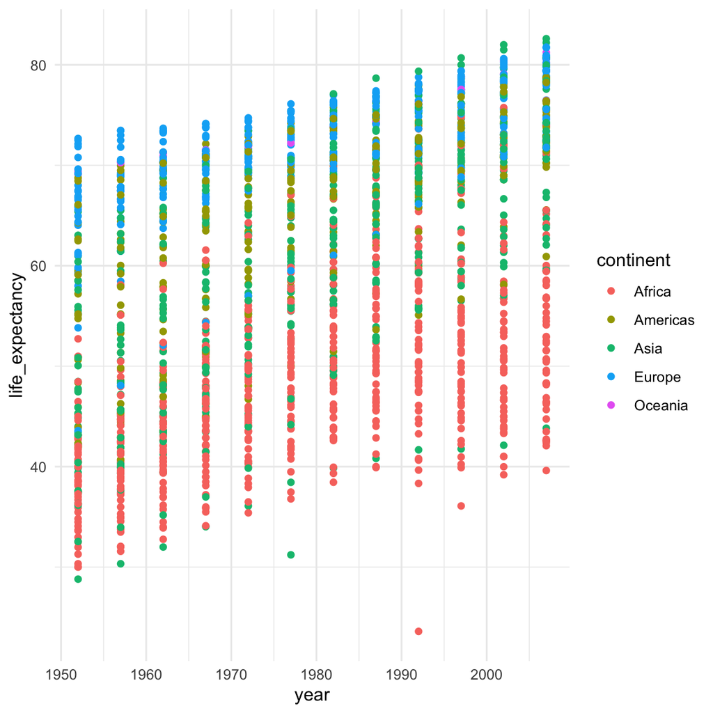

```r
# correct version
library(tidyverse)

# select only years after 1990
development %>%
  filter(year > 1990)
# A tibble: 568 x 6
   country     continent  year life_expectancy population gdp_per_capita
   <fct>       <fct>     <int>           <dbl>      <int>          <dbl>
 1 Afghanistan Asia       1992            41.7   16317921           649.
 2 Afghanistan Asia       1997            41.8   22227415           635.
 3 Afghanistan Asia       2002            42.1   25268405           727.
 4 Afghanistan Asia       2007            43.8   31889923           975.
 5 Albania     Europe     1992            71.6    3326498          2497.
 6 Albania     Europe     1997            73.0    3428038          3193.
 7 Albania     Europe     2002            75.7    3508512          4604.
 8 Albania     Europe     2007            76.4    3600523          5937.
 9 Algeria     Africa     1992            67.7   26298373          5023.
10 Algeria     Africa     1997            69.2   29072015          4797.
# … with 558 more rows

# calculate the average life expectancy in Africa
development %>%
  filter(continent == "Africa") %>%
  summarise(mean(life_expectancy))
# A tibble: 1 x 1
  `mean(life_expectancy)`
                    <dbl>
1                    48.9

development %>%
  ggplot(aes(year, life_expectancy, color=continent)) +
  geom_point()
```

# Check your knowledge

Write an answer to each of these questions in the `Check your knowledge` section of your workbook. The answers will be revealed in Session 3.

1. What is the `<-` symbol called and what does it do?
2. What is the `%>%` symbol called and what does it do?
3. Which function would you pipe a dataset into if you wanted to see the first few rows?
4. Which function is used to load data from a CSV file?
5. What must you do before you can load data on the RStudio server?
6. Which function is used to select rows from a dataset?
7. How would you select rows where values in a numeric column are between 10 and 20?
8. Which function is used to summarise data?
9. Which summary function would you use to calculate the mean of a numeric column?
10. How would you calculate the median of a subset of rows in a `data.frame`?

# Extension exercises

*Please remember that these extension exercises are *not* required to pass the course.* We include them because some students work through these materials much more quickly than others — perhaps because they have more previous experience with programming — and we aim to give all students the opportunity to stretch their skills.

If you do find you have extra time, however, these exercises are intended to provide additional practice in the technqiues taught here, and to be useful preparation for using R independently in a stage 4 or MSc research project.

**Extension exercise 1**

This output uses the `fuel` dataset to show vehicles with 8 cylinders and an engine size greater than 5 litres.

```
   mpg cyl engine_size power weight gear automatic
1 18.7   8        5900   175   1560    3     FALSE
2 14.3   8        5900   245   1619    3     FALSE
3 10.4   8        7730   205   2381    3     FALSE
4 10.4   8        7540   215   2460    3     FALSE
5 14.7   8        7210   230   2424    3     FALSE
6 15.5   8        5210   150   1597    3     FALSE
7 13.3   8        5740   245   1742    3     FALSE
8 19.2   8        6550   175   1744    3     FALSE
9 15.8   8        5750   264   1438    5      TRUE
```

In a new chunk, write the R code to produce this `data.frame`.

**Extension exercise 2**

Filter and summarise the `iris` dataset in order to answer the following question **to 2 decimal places**: